# Lecture 3: Circular flow and GDP

Macro I

Dr Theo Arvanitopoulos

# Circular flow and GDP

**Macro I**

How do millions of transactions become one measure of economic production?

By the end of this lecture, you should be able to:

- distinguish stocks from flows and explain the circular flow of production, income, and expenditure;
- define GDP and decide which transactions it includes;
- calculate GDP using expenditure, income, and value added;
- distinguish nominal GDP, real GDP, and the GDP deflator;
- evaluate GDP as a measure of production and wellbeing.

### 📚 Reading

Case, Fair, and Oster, *Principles of Macroeconomics*, Chapter 6.

# Stocks and flows

| Stock | Flow |
| --- | --- |
| measured at a point in time | measured over a period |
| wealth, population, capital | income, consumption, investment |
| inventory on 31 December | production during the year |

GDP is a **flow**. It records production during a stated period.

Prices are neither stocks nor flows. They are values measured at particular times.

# The participants and markets

The circular flow organises four groups:

- households;
- firms;
- government;
- the rest of the world.

They interact through the market for goods and services, the market for factors of production, and the financial sector.

The diagram records both real activity and the payments that accompany it.

# The circular flow

[figure not shown]

# Households and firms

*Households.* Supply labour, land, capital, and entrepreneurship; receive wages, rent, interest, and profits.

They use income to consume, pay taxes, and save.

*Firms.* Hire production inputs, produce output, and pay factor incomes.

*Financial link.* Household saving supplies funds that can finance business investment.

One participant’s payment is another participant’s receipt.

# Government, trade, and finance

*Government.* Collects taxes, buys goods and services, and makes social transfers.

Transfers redistribute income; they do not purchase current output.

*Financial sector.* Connects household saving with borrowing and business investment.

Buying an existing financial asset changes ownership; financing new capital supports investment in production.

*Rest of the world.* Buys exports and supplies imports. Net exports equal exports minus imports.

The dotted boundary encloses domestic households, firms, government, markets, and finance. The separate box identifies the rest of the world.

# Output, income, and expenditure

Firms receive revenue when buyers purchase final output.

That revenue becomes wages, rent, interest, or profits for the owners of factors of production.

Therefore:

$$\text{total output}=\text{total
income}=\text{total expenditure}$$

This is an accounting identity. It does not claim that output equals potential output or that every market clears.

# Gross domestic product

**GDP is the market value of all new, final goods and services produced within a country during a given period.**

Each part of the definition sets a boundary for what counts in GDP:

- *Market value:* puts different products into pounds.
- *New:* excludes goods produced in earlier periods.
- *Final:* avoids counting intermediate inputs twice.
- *Within a country:* follows where production takes place.
- *During a period:* makes GDP a flow, usually measured quarterly or annually.

# What GDP includes

For each final product, market value is its price multiplied by the quantity produced: $P\times Q$.

Adding these values gives the market value of output. For example, 100 loaves at £2 each contribute £200.

GDP includes current production even when no final customer has yet purchased it.

- New inventories count as investment.
- New housing counts as residential investment.
- Government services enter mainly at their production cost.
- Owner-occupied housing enters through an imputed rental value.

National accountants use conventions to make the boundary consistent.

# What GDP excludes

GDP excludes transactions that do not represent current production:

- sales of used goods;
- purchases of shares or bonds;
- transfer payments;
- intermediate goods counted separately from the final product.

Brokerage or dealership services associated with a transaction do count because they are current services.

# Does it count in GDP?

A newly produced car sold in the UK?

**Yes.** It is current, final production.

A used car resold privately?

**No.** It was counted when first produced.

A dealer’s fee on that used car?

**Yes.** The dealer provides a current service.

Bread sold to a household?

**Yes.** It is a final good.

Flour bought by the bakery?

**No, not separately.** Its value is included in the bread.

Bread produced and added to inventory?

**Yes.** It counts as inventory investment.

The question is whether current domestic production occurred.

# GDP and national output

GDP follows the **location of production**.

**Gross national product (GNP)** values output produced by factors owned by a country’s nationals, including production abroad.

Production at a foreign-owned UK factory contributes to UK GDP. Production by a UK national working abroad contributes to the national measure.

**Gross national income (GNI)** tracks income accruing to a country’s residents. The essential distinction is *where production occurs* versus *to whom income accrues*.

# Three ways to measure GDP

The same production can be viewed from three directions:

1. **Expenditure:** add spending on final output.
2. **Income:** add income generated as that output is produced.
3. **Value added:** add each producer’s contribution, excluding inputs bought from other producers.

The first two follow the flow of payments.

Value added follows production stage by stage.

In principle, all three give the same GDP; taxes, subsidies, and measurement differences require care in practice.

# Expenditure approach

$$Y=C+I+G+NX, \qquad NX=X-M$$

- $C$: household consumption;
- $I$: business capital, new housing, and inventories;
- $G$: government purchases of current goods and services;
- $NX$: exports minus imports.

Imports are subtracted because they may already appear inside $C$, $I$, or $G$ but are not domestic production.

# Consumption and investment

Consumption includes household spending on durable goods, non-durable goods, and services.

Investment means additions to productive capital or inventories:

- machinery and structures;
- new housing;
- changes in inventories.

Purchasing an existing financial asset transfers ownership. It does not create new capital for GDP accounting.

# Government purchases and transfers

Government purchases include public services, employee compensation, and infrastructure.

**Pensions** and **welfare benefits** are **transfers**. They enter GDP only when recipients spend the income on newly produced goods and services.

**Interest** on **government** debt is also treated as a transfer in the textbook’s national accounts framework.

# Expenditure in practice

This 2017 US example shows the four components of GDP. Consumption is the largest; net exports are negative.

[figure not shown]

# Worked expenditure example

Suppose an economy records, in £ billions:

| $C$ | $I$ | $G$ | $X$ | $M$ |
| --- | --- | --- | --- | --- |
| 391 | 136 | 150 | 82 | 111 |

$$NX=82-111=-29$$

$$GDP=391+136+150-29=£648\text{
billion}$$

# Income approach

*Who receives the income generated by production?* National income adds eight items:

1. **Compensation of employees:** wages, salaries, and employer pension and social contributions.
2. **Proprietors’ income:** income of unincorporated businesses.
3. **Rental income:** income received by property owners as rent.
4. **Corporate profits:** income of incorporated businesses.
5. **Net interest:** interest paid by businesses arising from production.
6. **Indirect taxes less subsidies:** taxes on goods and services, less related subsidies.
7. **Net business transfers:** transfers paid by businesses to others, net of transfers received.
8. **Surplus of government enterprises:** income or losses of government-owned businesses.

National income is not identical to GDP; depreciation and cross-border factor income require further adjustments.

# National income in practice

In this 2017 US example, employee compensation is the largest component of national income.

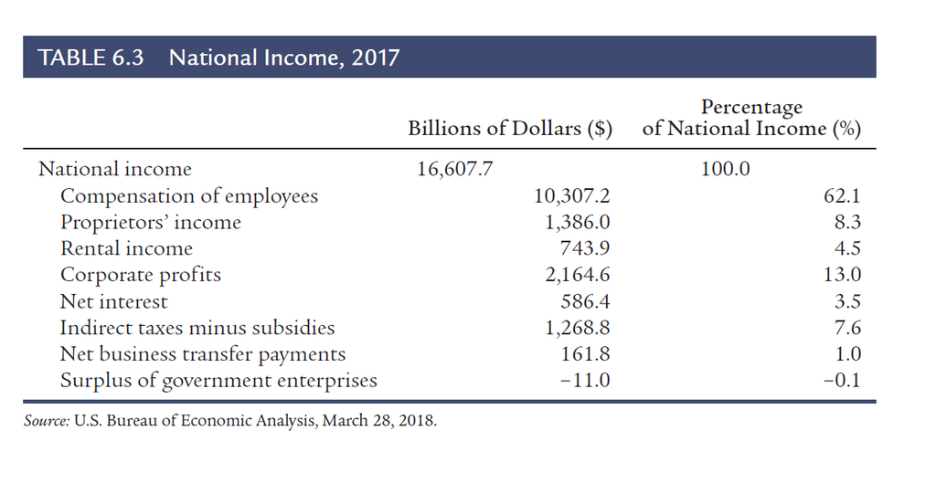

# From GDP to household income

1. **GDP to national income**  
   Adjust for cross-border income, depreciation, and statistical differences. GDP is domestic and gross; national income follows income earned by a country’s factors of production.
2. **National to personal income**  
   Remove income firms retain, and include transfers households receive. Transfers redistribute income; they are not new output.
3. **Personal to disposable income**  
   Subtract personal taxes. The result is income households can spend or save.

In our **simplified household model**, $Y_d$ (disposable income) is divided between $C$ (consumption) and $S$ (saving):

$$Y_d=C+S.$$

# Value added prevents double counting

| Stage | Sales | Intermediate inputs | Value added |
| --- | --- | --- | --- |
| farmer sells wheat | £20 | £0 | £20 |
| miller sells flour | £35 | £20 | £15 |
| baker sells bread | £60 | £35 | £25 |
| **total value added** |  |  | **£60** |

The sum of value added equals the final sale.

# Inventories and depreciation

Goods produced but not sold add to inventories and count as current investment.

Gross investment includes replacement of worn-out capital.

$$\text{net investment}=\text{gross
investment}-\text{depreciation}$$

Consequently:

$$K_{t+1}=K_t+\text{net
investment}.$$

# Measurement in practice

In theory, the expenditure, income, and production approaches agree.

The production approach first measures gross value added at basic prices:

$$GDP_{market}=GVA_{basic}+\text{taxes on
products}-\text{subsidies on products}.$$

In practice, timing differences and incomplete observations create a statistical discrepancy.

Agencies revise estimates as more complete information arrives. Revision does not mean that the accounting identity failed.

# Nominal GDP combines prices and quantities

For goods $i=1,\ldots,n$:

$$GDP_t^{nominal}=\sum_i
P_{it}Q_{it}.$$

A rise in nominal GDP may reflect greater production, higher prices, or both.

Real GDP separates quantity change by valuing production with a common price basis.

# A two-good economy

| Year | Apple price | Apple quantity | Banana price | Banana quantity |
| --- | --- | --- | --- | --- |
| 2010 | £2.00 | 150 | £1.00 | 100 |
| 2020 | £2.50 | 200 | £2.00 | 200 |

Nominal GDP in 2010: $2(150)+1(100)=£400$.

Nominal GDP in 2020: $2.5(200)+2(200)=£900$.

Nominal GDP rose by 125%, but prices and quantities both changed.

# Real GDP holds prices constant

Using 2010 prices:

$$GDP_{2020}^{real}=2(200)+1(200)=£600.$$

$$\text{real
growth}=\frac{600-400}{400}\times100=50\%.$$

The calculation attributes the remaining change in nominal GDP to prices.

Official statistics commonly use chain-linked volume measures rather than one fixed base year for every comparison.

# The GDP deflator

$$\text{GDP
deflator}_t=\frac{GDP_t^{nominal}}{GDP_t^{real}}\times100.$$

| Year | Nominal GDP | Real GDP at 2010 prices |
| --- | --- | --- |
| 2010 | £400 | £400 |
| 2020 | £900 | £600 |

For the base year:

$$\text{GDP
deflator}_{2010}=\frac{400}{400}\times100=100.$$

For 2020:

$$\text{GDP
deflator}_{2020}=\frac{900}{600}\times100=150.$$

The deflator equals 100 in the base year.

In this example, the price level for domestically produced final output is 50% higher in 2020 than in 2010.

# GDP and wellbeing

GDP measures recorded production. It does not directly measure wellbeing.

More production may increase the resources available to society, but the welfare effect also depends on what is produced, how it is produced, and who benefits.

GDP remains useful when interpreted as a production measure rather than a complete social scorecard.

# Important limitations

GDP may miss or inadequately represent:

- unpaid household work and care;
- informal and unreported activity;
- leisure and working conditions;
- environmental damage and resource depletion;
- the distribution of income;
- changes in quality that statistics capture imperfectly.

Cross-country comparisons also require attention to population, prices, and purchasing power.

# Interpreting a change in GDP

Before treating higher GDP as economic improvement, ask:

1. Is the figure nominal or real?
2. Did total GDP or GDP per person change?
3. Was the change temporary or persistent?
4. Did unmeasured costs or benefits change?
5. How was the resulting income distributed?

These questions supplement GDP rather than replace it.

# Summary

- The circular flow connects output, income, and expenditure.
- GDP measures new final production within a country’s borders.
- Expenditure, income, and value added are three views of the same activity.
- Real GDP isolates quantity change; nominal GDP combines prices and quantities.
- The GDP deflator measures prices of domestic final output.
- GDP is central to macroeconomics but incomplete as a measure of wellbeing.

**Next lecture:** inflation, unemployment, and interest rates, including the consumer price index.